# Project- Concrete Strength Prediction

## Concrete Strength Prediction

### Objective

To predict the concrete strength using the data available in file concrete_data.xls. Apply feature engineering and model tuning to obtain 80% to 95% of R2score.

### Resources Available

The data for this project is available in file https://archive.ics.uci.edu/ml/machine-learning-databases/concrete/compressive/. The same has been shared along with the course content.

### Attribute Information:

Given are the variable name, variable type, the measurement unit and a brief description. The concrete compressive strength is the regression problem. The order of this listing corresponds to the order of numerals along the rows of the database.

Name -- Data Type -- Measurement -- Description  
Cement (cement) -- quantitative -- kg in a m3 mixture -- Input Variable  
Blast Furnace Slag (slag) -- quantitative -- kg in a m3 mixture -- Input Variable  
Fly Ash (ash) -- quantitative -- kg in a m3 mixture -- Input Variable  
Water (water) -- quantitative -- kg in a m3 mixture -- Input Variable  
Superplasticizer (superplastic) -- quantitative -- kg in a m3 mixture -- Input Variable  
Coarse Aggregate (coarseagg) -- quantitative -- kg in a m3 mixture -- Input Variable  
Fine Aggregate (fineagg) -- quantitative -- kg in a m3 mixture -- Input Variable  
Age(age) -- quantitative -- Day (1~365) -- Input Variable  
Concrete compressive strength(strength) -- quantitative -- MPa -- Output Variable

```python
def warn(*args, **kwargs):
    pass
import warnings
warnings.warn = warn

#For numerical libraries
import numpy as np
#To handle data in the form of rows and columns
import pandas as pd
#importing seaborn for statistical plots
import seaborn as sns
#importing ploting libraries
import matplotlib.pyplot as plt
#styling figures
plt.rc('font',size=14)
sns.set(style='white')
sns.set(style='whitegrid',color_codes=True)
#To enable plotting graphs in Jupyter notebook
%matplotlib inline
#importing the feature scaling library
from sklearn.preprocessing import StandardScaler
#Import Sklearn package's data splitting function which is based on random function
from sklearn.model_selection import train_test_split
# Import Linear Regression, Ridge and Lasso machine learning library
from sklearn.linear_model import LinearRegression, Ridge, Lasso

from sklearn.metrics import classification_report, confusion_matrix,recall_score, precision_score, f1_score, roc_auc_score,accuracy_score

# Import KNN Regressor machine learning library
from sklearn.neighbors import KNeighborsRegressor
# Import Decision Tree Regressor machine learning library
from sklearn.tree import DecisionTreeRegressor
# Import ensemble machine learning library
from sklearn.ensemble import (RandomForestRegressor, GradientBoostingRegressor,AdaBoostRegressor,BaggingRegressor)
# Import support vector regressor machine learning library
from sklearn.svm import SVR
#Import the metrics
from sklearn import metrics
#Import the Voting regressor for Ensemble
from sklearn.ensemble import VotingRegressor
# Import stats from scipy
from scipy import stats
# Import zscore for scaling
from scipy.stats import zscore
#importing the metrics
from sklearn.metrics import mean_squared_error,mean_absolute_error,r2_score
#importing the K fold
from sklearn.model_selection import KFold
#importing the cross validation score
from sklearn.model_selection import cross_val_score
#importing the preprocessing library
from sklearn import preprocessing
# importing the Polynomial features
from sklearn.preprocessing import PolynomialFeatures
#importing kmeans clustering library
from sklearn.cluster import KMeans
from sklearn.utils import resample

from sklearn.neighbors import KNeighborsRegressor

from sklearn.ensemble import RandomForestRegressor
from sklearn.linear_model import LogisticRegression
```

```python
#reading the CSV file into pandas dataframe
concrete_df=pd.read_csv('concrete.csv')
```

```python
#Check top few records of the dataset
concrete_df.head()
```

|  | cement | slag | ash | water | superplastic | coarseagg | fineagg | age | strength |
| --- | --- | --- | --- | --- | --- | --- | --- | --- | --- |
| 0 | 141.3 | 212.0 | 0.0 | 203.5 | 0.0 | 971.8 | 748.5 | 28 | 29.89 |
| 1 | 168.9 | 42.2 | 124.3 | 158.3 | 10.8 | 1080.8 | 796.2 | 14 | 23.51 |
| 2 | 250.0 | 0.0 | 95.7 | 187.4 | 5.5 | 956.9 | 861.2 | 28 | 29.22 |
| 3 | 266.0 | 114.0 | 0.0 | 228.0 | 0.0 | 932.0 | 670.0 | 28 | 45.85 |
| 4 | 154.8 | 183.4 | 0.0 | 193.3 | 9.1 | 1047.4 | 696.7 | 28 | 18.29 |

STEPS:

### 1. Exploratory data quality report reflecting the following:

1. Univariate analysis – data types and description of the independent attributes which should include (name, meaning, range of values observed, central values (mean and median), standard deviation and quartiles, analysis of the body of distributions / tails, missing values, outliers (10 Marks)
2. Bi-variate analysis between the predictor variables and between the predictor variables and target column. Comment on your findings in terms of their relationship and degree of relation if any. Visualize the analysis using boxplots and pair plots, histograms or density curves. (10 marks)

```python
#To show the detailed summary
concrete_df.info()
```

```
<class 'pandas.core.frame.DataFrame'>
RangeIndex: 1030 entries, 0 to 1029
Data columns (total 9 columns):
 #   Column        Non-Null Count  Dtype
---  ------        --------------  -----
 0   cement        1030 non-null   float64
 1   slag          1030 non-null   float64
 2   ash           1030 non-null   float64
 3   water         1030 non-null   float64
 4   superplastic  1030 non-null   float64
 5   coarseagg     1030 non-null   float64
 6   fineagg       1030 non-null   float64
 7   age           1030 non-null   int64
 8   strength      1030 non-null   float64
dtypes: float64(8), int64(1)
memory usage: 72.5 KB
```

```python
concrete_df.shape
```

```
(1030, 9)
```

```python
#Checking for missing values
concrete_df.isnull().sum()
```

```
cement          0
slag            0
ash             0
water           0
superplastic    0
coarseagg       0
fineagg         0
age             0
strength        0
dtype: int64
```

```python
duplicateRowsDF = concrete_df[concrete_df.duplicated()]
print("Duplicate Rows except first occurrence based on all columns are :")
print(duplicateRowsDF)
```

```
Duplicate Rows except first occurrence based on all columns are :
     cement   slag  ash  water  superplastic  coarseagg  fineagg  age  \
278   425.0  106.3  0.0  153.5          16.5      852.1    887.1    3
298   425.0  106.3  0.0  153.5          16.5      852.1    887.1    3
400   362.6  189.0  0.0  164.9          11.6      944.7    755.8    3
420   362.6  189.0  0.0  164.9          11.6      944.7    755.8    3
463   362.6  189.0  0.0  164.9          11.6      944.7    755.8   56
468   252.0    0.0  0.0  185.0           0.0     1111.0    784.0   28
482   425.0  106.3  0.0  153.5          16.5      852.1    887.1   91
493   362.6  189.0  0.0  164.9          11.6      944.7    755.8   91
517   425.0  106.3  0.0  153.5          16.5      852.1    887.1   56
525   362.6  189.0  0.0  164.9          11.6      944.7    755.8   28
527   425.0  106.3  0.0  153.5          16.5      852.1    887.1   91
576   362.6  189.0  0.0  164.9          11.6      944.7    755.8    7
577   425.0  106.3  0.0  153.5          16.5      852.1    887.1   28
```

[output cut: 39 more lines]

```python
#drop duplicates
concrete_df=concrete_df.drop_duplicates()
```

```python
concrete_df.shape
```

```
(1005, 9)
```

```python
# Data types information
concrete_df.dtypes
```

```
cement          float64
slag            float64
ash             float64
water           float64
superplastic    float64
coarseagg       float64
fineagg         float64
age               int64
strength        float64
dtype: object
```

```python
#To get the shape
concrete_df.shape
```

```
(1005, 9)
```

```python
#To get the columns name
concrete_df.columns
```

```
Index(['cement', 'slag', 'ash', 'water', 'superplastic', 'coarseagg',
       'fineagg', 'age', 'strength'],
      dtype='object')
```

```python
#Analyze the distribution of the dataset
concrete_df.describe().T
```

|  | count | mean | std | min | 25% | 50% | 75% | max |
| --- | --- | --- | --- | --- | --- | --- | --- | --- |
| cement | 1005.0 | 278.631343 | 104.344261 | 102.00 | 190.70 | 265.0 | 349.00 | 540.0 |
| slag | 1005.0 | 72.043483 | 86.170807 | 0.00 | 0.00 | 20.0 | 142.50 | 359.4 |
| ash | 1005.0 | 55.536318 | 64.207969 | 0.00 | 0.00 | 0.0 | 118.30 | 200.1 |
| water | 1005.0 | 182.075323 | 21.339334 | 121.80 | 166.60 | 185.7 | 192.90 | 247.0 |
| superplastic | 1005.0 | 6.033234 | 5.919967 | 0.00 | 0.00 | 6.1 | 10.00 | 32.2 |
| coarseagg | 1005.0 | 974.376816 | 77.579667 | 801.00 | 932.00 | 968.0 | 1031.00 | 1145.0 |
| fineagg | 1005.0 | 772.688259 | 80.340435 | 594.00 | 724.30 | 780.0 | 822.20 | 992.6 |
| age | 1005.0 | 45.856716 | 63.734692 | 1.00 | 7.00 | 28.0 | 56.00 | 365.0 |
| strength | 1005.0 | 35.250378 | 16.284815 | 2.33 | 23.52 | 33.8 | 44.87 | 82.6 |

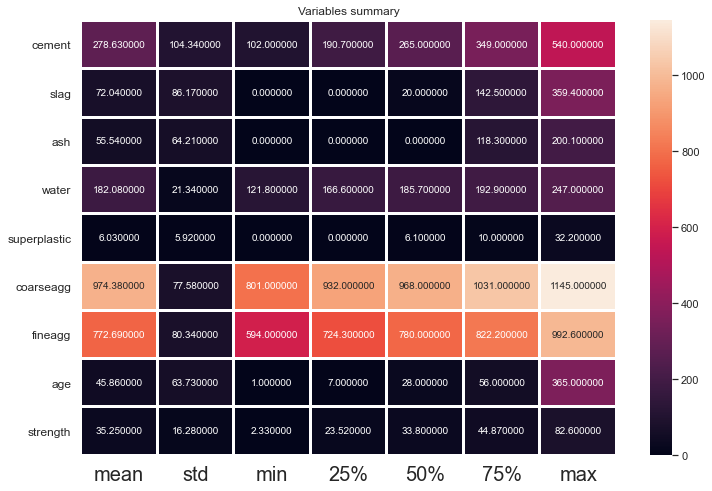

```python
plt.figure(figsize=(12,8))
sns.heatmap(round(concrete_df.describe()[1:].transpose(),2),linewidth=2,annot=True,fmt="f")
plt.xticks(fontsize=20)
plt.yticks(fontsize=12)
plt.title("Variables summary")
plt.show()
```

```python
concrete_df['cement'].median()
```

```
265.0
```

```python
def df_col_analysis(df, fieldName, targetfield):
    maxVal= df[fieldName].max()
    minVal=df[fieldName].min()
    Q1=df[fieldName].quantile(q=0.25)
    Q3=df[fieldName].quantile(q=0.75)
    L_outliers=Q1-1.5*(Q3-Q1)
    U_outliers=Q3+1.5*(Q3-Q1)
    print(fieldName + ': Range : ', minVal, '-', maxVal)
    print(fieldName + ': Mean : ', df[fieldName].mean())
    print(fieldName + ': Median : ', df[fieldName].median())
    print(fieldName + ': Std Dev : ', df[fieldName].std())
    print(fieldName + ': Lower outliers : ', L_outliers)
    print(fieldName + ': upper outliers : ', U_outliers)
    print(fieldName + ': Number of outliers in  upper : ', df[df[fieldName]>U_outliers][fieldName].count())
    print(fieldName + ': Number of outliers in  lower : ', df[df[fieldName]<L_outliers][fieldName].count())
    print(fieldName + ': % of Outlier in  upper: ',round(df[df[fieldName]>U_outliers][fieldName].count()*100/len(df)), '%')
    print(fieldName + ': % of Outlier in  lower: ',round(df[df[fieldName]<L_outliers][fieldName].count()*100/len(df)), '%')

    fig, (ax1,ax2,ax3)=plt.subplots(1,3,figsize=(13,5))

    #boxplot
    sns.boxplot(x=fieldName,data=df,orient='v',ax=ax1)
    ax1.set_ylabel(fieldName, fontsize=15)
    ax1.set_title('Distribution of '+ fieldName, fontsize=15)
    ax1.tick_params(labelsize=15)

    #distplot
    sns.distplot(df[fieldName],ax=ax2)
    ax2.set_xlabel(fieldName, fontsize=15)
    ax2.set_ylabel(targetfield, fontsize=15)
    plt.axvline(df[fieldName].mean(),linestyle="dashed",label="mean",color="k")
    plt.legend(loc="best")
    plt.xlabel("")
    ax2.set_title( fieldName + ' vs '+ targetfield, fontsize=15)
    ax2.tick_params(labelsize=15)

    #histogram
    ax3.hist(df[fieldName])
    ax3.set_xlabel(fieldName, fontsize=15)
    ax3.set_ylabel(targetfield, fontsize=15)
    ax3.set_title(fieldName + ' vs ' + targetfield, fontsize=15)
    ax3.tick_params(labelsize=15)

    plt.subplots_adjust(wspace=0.5)
    plt.tight_layout()
```

```
cement: Range :  102.0 - 540.0
cement: Mean :  278.631343283582
cement: Median :  265.0
cement: Std Dev :  104.34426071285247
cement: Lower outliers :  -46.75000000000003
cement: upper outliers :  586.45
cement: Number of outliers in  upper :  0
cement: Number of outliers in  lower :  0
cement: % of Outlier in  upper:  0.0 %
cement: % of Outlier in  lower:  0.0 %
```

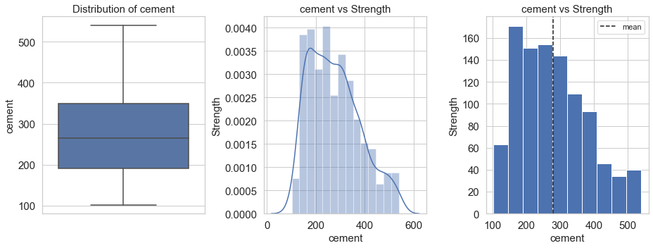

```python
df_col_analysis(concrete_df,'cement', 'Strength')
```

```
slag: Range :  0.0 - 359.4
slag: Mean :  72.04348258706466
slag: Median :  20.0
slag: Std Dev :  86.17080699343262
slag: Lower outliers :  -213.75
slag: upper outliers :  356.25
slag: Number of outliers in  upper :  2
slag: Number of outliers in  lower :  0
slag: % of Outlier in  upper:  0.0 %
slag: % of Outlier in  lower:  0.0 %
```

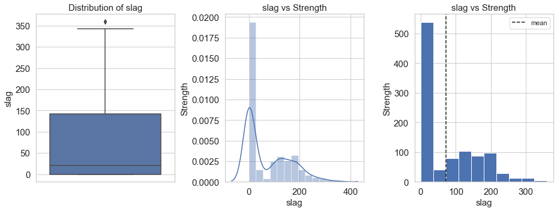

```python
df_col_analysis(concrete_df,'slag', 'Strength')
```

```
ash: Range :  0.0 - 200.1
ash: Mean :  55.53631840796018
ash: Median :  0.0
ash: Std Dev :  64.20796859777033
ash: Lower outliers :  -177.45
ash: upper outliers :  295.75
ash: Number of outliers in  upper :  0
ash: Number of outliers in  lower :  0
ash: % of Outlier in  upper:  0.0 %
ash: % of Outlier in  lower:  0.0 %
```

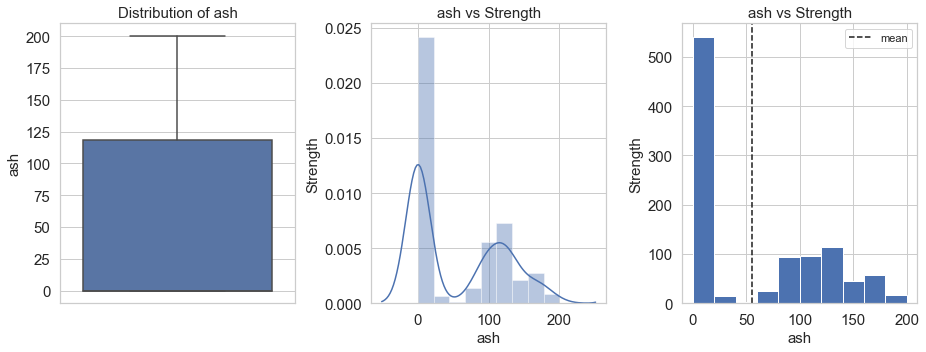

```python
df_col_analysis(concrete_df,'ash', 'Strength')
```

```
water: Range :  121.8 - 247.0
water: Mean :  182.07532338308457
water: Median :  185.7
water: Std Dev :  21.339334087611324
water: Lower outliers :  127.14999999999998
water: upper outliers :  232.35000000000002
water: Number of outliers in  upper :  4
water: Number of outliers in  lower :  11
water: % of Outlier in  upper:  0.0 %
water: % of Outlier in  lower:  1.0 %
```

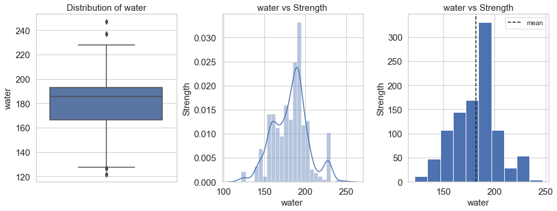

```python
df_col_analysis(concrete_df,'water', 'Strength')
```

```
superplastic: Range :  0.0 - 32.2
superplastic: Mean :  6.033233830845768
superplastic: Median :  6.1
superplastic: Std Dev :  5.9199667200234325
superplastic: Lower outliers :  -15.0
superplastic: upper outliers :  25.0
superplastic: Number of outliers in  upper :  10
superplastic: Number of outliers in  lower :  0
superplastic: % of Outlier in  upper:  1.0 %
superplastic: % of Outlier in  lower:  0.0 %
```

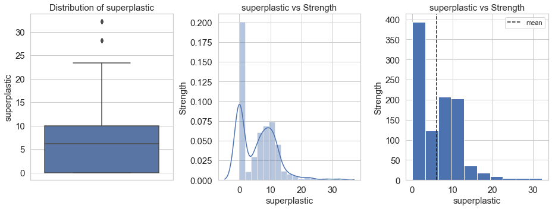

```python
df_col_analysis(concrete_df,'superplastic', 'Strength')
```

```
coarseagg: Range :  801.0 - 1145.0
coarseagg: Mean :  974.3768159203987
coarseagg: Median :  968.0
coarseagg: Std Dev :  77.57966673714671
coarseagg: Lower outliers :  783.5
coarseagg: upper outliers :  1179.5
coarseagg: Number of outliers in  upper :  0
coarseagg: Number of outliers in  lower :  0
coarseagg: % of Outlier in  upper:  0.0 %
coarseagg: % of Outlier in  lower:  0.0 %
```

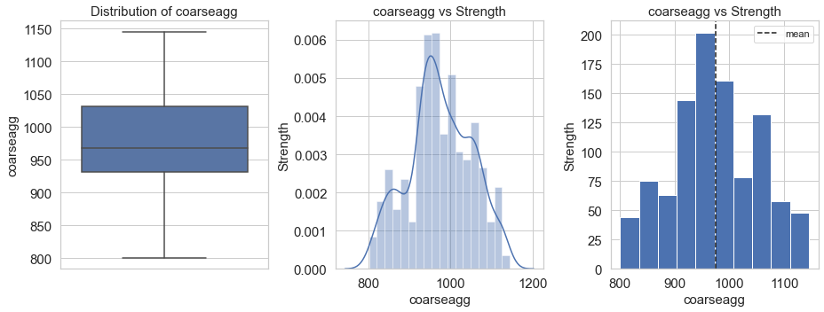

```python
df_col_analysis(concrete_df,'coarseagg', 'Strength')
```

```
fineagg: Range :  594.0 - 992.6
fineagg: Mean :  772.6882587064675
fineagg: Median :  780.0
fineagg: Std Dev :  80.34043464964547
fineagg: Lower outliers :  577.4499999999998
fineagg: upper outliers :  969.0500000000002
fineagg: Number of outliers in  upper :  5
fineagg: Number of outliers in  lower :  0
fineagg: % of Outlier in  upper:  0.0 %
fineagg: % of Outlier in  lower:  0.0 %
```

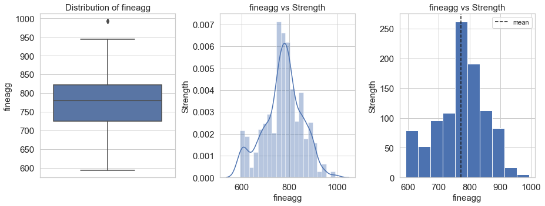

```python
df_col_analysis(concrete_df,'fineagg', 'Strength')
```

```
age: Range :  1 - 365
age: Mean :  45.85671641791045
age: Median :  28.0
age: Std Dev :  63.734691679416535
age: Lower outliers :  -66.5
age: upper outliers :  129.5
age: Number of outliers in  upper :  59
age: Number of outliers in  lower :  0
age: % of Outlier in  upper:  6.0 %
age: % of Outlier in  lower:  0.0 %
```

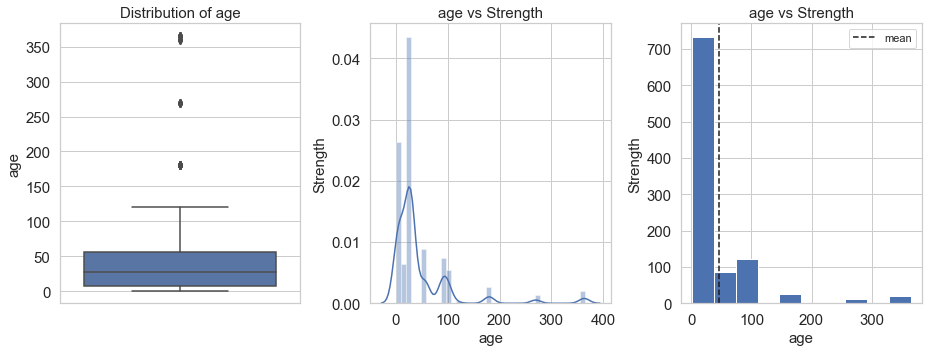

```python
df_col_analysis(concrete_df,'age', 'Strength')
```

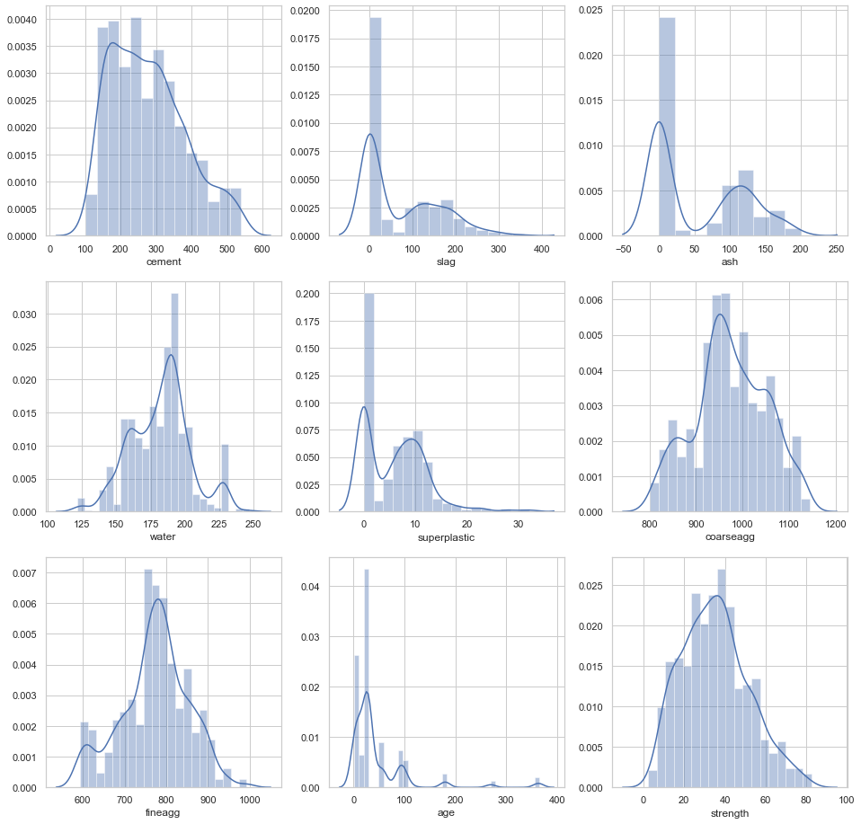

```python
# Distplot
fig, ax2 = plt.subplots(3, 3, figsize=(16, 16))
sns.distplot(concrete_df['cement'],ax=ax2[0][0])
sns.distplot(concrete_df['slag'],ax=ax2[0][1])
sns.distplot(concrete_df['ash'],ax=ax2[0][2])
sns.distplot(concrete_df['water'],ax=ax2[1][0])
sns.distplot(concrete_df['superplastic'],ax=ax2[1][1])
sns.distplot(concrete_df['coarseagg'],ax=ax2[1][2])
sns.distplot(concrete_df['fineagg'],ax=ax2[2][0])
sns.distplot(concrete_df['age'],ax=ax2[2][1])
sns.distplot(concrete_df['strength'],ax=ax2[2][2])
```

[output not shown]

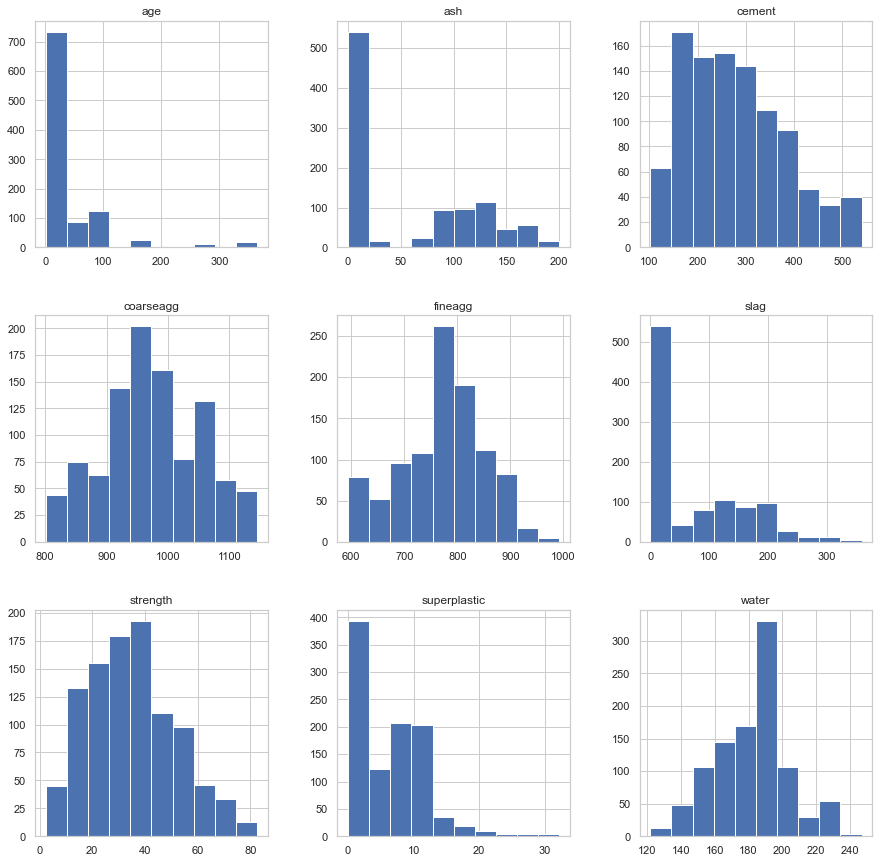

```python
# Histogram
concrete_df.hist(figsize=(15,15))
```

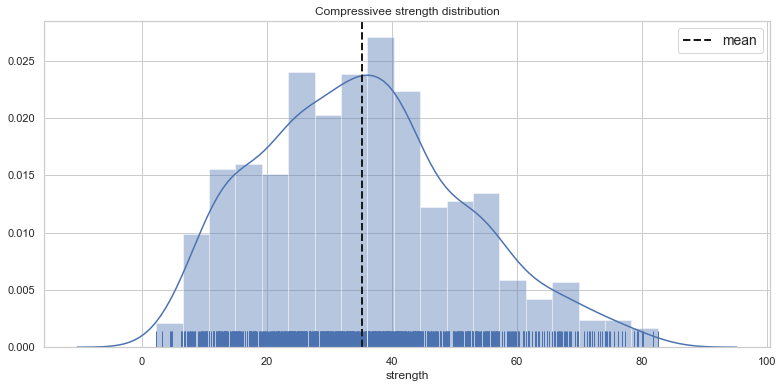

```python
plt.figure(figsize=(13,6))
sns.distplot(concrete_df["strength"],color="b",rug=True)
plt.axvline(concrete_df["strength"].mean(),
            linestyle="dashed",color="k",
            label='mean',linewidth=2)
plt.legend(loc="best",prop={"size":14})
plt.title("Compressivee strength distribution")
plt.show()
```

```python
#In order to make this easier to interpret, stratify CS into bins in order to make your visual
#representations easier to interpret.

concrete_df['cs_binned'] = pd.cut(concrete_df['strength'], bins=12, labels=False).values
```

```python
concrete_df
```

|  | cement | slag | ash | water | superplastic | coarseagg | fineagg | age | strength | cs_binned |
| --- | --- | --- | --- | --- | --- | --- | --- | --- | --- | --- |
| 0 | 141.3 | 212.0 | 0.0 | 203.5 | 0.0 | 971.8 | 748.5 | 28 | 29.89 | 4 |
| 1 | 168.9 | 42.2 | 124.3 | 158.3 | 10.8 | 1080.8 | 796.2 | 14 | 23.51 | 3 |
| 2 | 250.0 | 0.0 | 95.7 | 187.4 | 5.5 | 956.9 | 861.2 | 28 | 29.22 | 4 |
| 3 | 266.0 | 114.0 | 0.0 | 228.0 | 0.0 | 932.0 | 670.0 | 28 | 45.85 | 6 |
| 4 | 154.8 | 183.4 | 0.0 | 193.3 | 9.1 | 1047.4 | 696.7 | 28 | 18.29 | 2 |
| ... | ... | ... | ... | ... | ... | ... | ... | ... | ... | ... |
| 1025 | 135.0 | 0.0 | 166.0 | 180.0 | 10.0 | 961.0 | 805.0 | 28 | 13.29 | 1 |
| 1026 | 531.3 | 0.0 | 0.0 | 141.8 | 28.2 | 852.1 | 893.7 | 3 | 41.30 | 5 |
| 1027 | 276.4 | 116.0 | 90.3 | 179.6 | 8.9 | 870.1 | 768.3 | 28 | 44.28 | 6 |
| 1028 | 342.0 | 38.0 | 0.0 | 228.0 | 0.0 | 932.0 | 670.0 | 270 | 55.06 | 7 |
| 1029 | 540.0 | 0.0 | 0.0 | 173.0 | 0.0 | 1125.0 | 613.0 | 7 | 52.61 | 7 |

1005 rows × 10 columns

[output not shown]

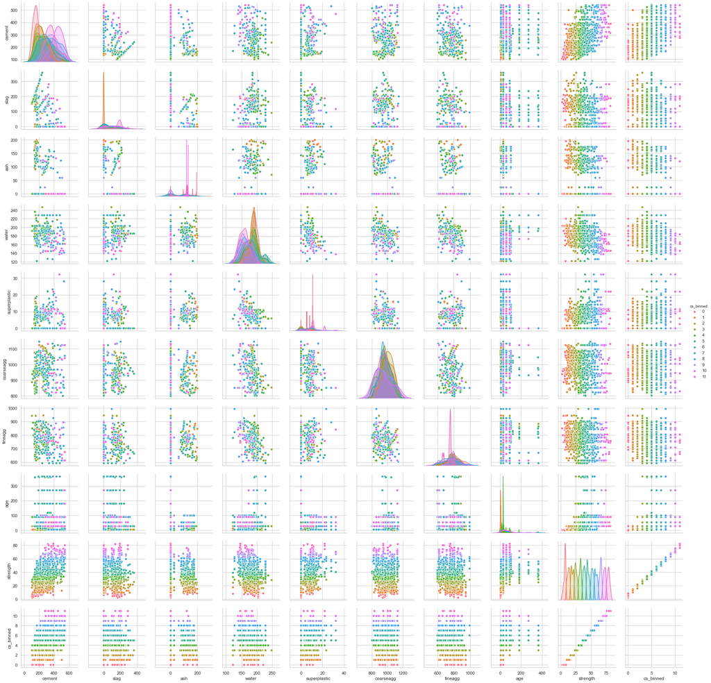

```python
def warn(*args, **kwargs):
    pass
import warnings
warnings.warn = warn

# pairplot- plot density curve instead of histogram in diagonal
sns.pairplot(concrete_df,
             hue='cs_binned',
             palette="husl")
```

```python
# corrlation matrix
cor=concrete_df.corr()
cor
```

|  | cement | slag | ash | water | superplastic | coarseagg | fineagg | age | strength | cs_binned |
| --- | --- | --- | --- | --- | --- | --- | --- | --- | --- | --- |
| cement | 1.000000 | -0.303324 | -0.385610 | -0.056625 | 0.060906 | -0.086205 | -0.245375 | 0.086348 | 0.488283 | 0.482554 |
| slag | -0.303324 | 1.000000 | -0.312352 | 0.130262 | 0.019800 | -0.277559 | -0.289685 | -0.042759 | 0.103374 | 0.104921 |
| ash | -0.385610 | -0.312352 | 1.000000 | -0.283314 | 0.414213 | -0.026468 | 0.090262 | -0.158940 | -0.080648 | -0.081820 |
| water | -0.056625 | 0.130262 | -0.283314 | 1.000000 | -0.646946 | -0.212480 | -0.444915 | 0.279284 | -0.269624 | -0.263780 |
| superplastic | 0.060906 | 0.019800 | 0.414213 | -0.646946 | 1.000000 | -0.241721 | 0.207993 | -0.194076 | 0.344209 | 0.337860 |
| coarseagg | -0.086205 | -0.277559 | -0.026468 | -0.212480 | -0.241721 | 1.000000 | -0.162187 | -0.005264 | -0.144717 | -0.142673 |
| fineagg | -0.245375 | -0.289685 | 0.090262 | -0.444915 | 0.207993 | -0.162187 | 1.000000 | -0.156572 | -0.186448 | -0.188456 |
| age | 0.086348 | -0.042759 | -0.158940 | 0.279284 | -0.194076 | -0.005264 | -0.156572 | 1.000000 | 0.337367 | 0.334642 |
| strength | 0.488283 | 0.103374 | -0.080648 | -0.269624 | 0.344209 | -0.144717 | -0.186448 | 0.337367 | 1.000000 | 0.993421 |
| cs_binned | 0.482554 | 0.104921 | -0.081820 | -0.263780 | 0.337860 | -0.142673 | -0.188456 | 0.334642 | 0.993421 | 1.000000 |

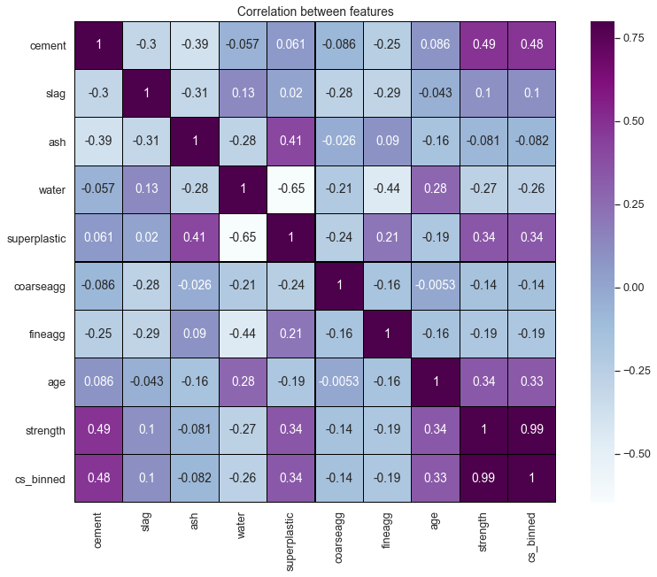

```python
#heatmap
sns.set(font_scale=1.15)
plt.figure(figsize=(14, 10))

sns.heatmap(cor, vmax=.8, linewidths=0.01,
            square=True,annot=True,cmap="BuPu",linecolor="black")
plt.title('Correlation between features');
```

## Analysis

High correlation : Cement , Age and Super Plasticizer are main factors influencing Compressive strength.  
Strong negative correlation between Super Plasticizer and Water.  
positive correlations between Super Plasticizer and Fly Ash, Fine Aggregate.

### CC_Strength vs (Cement, Age, Water)

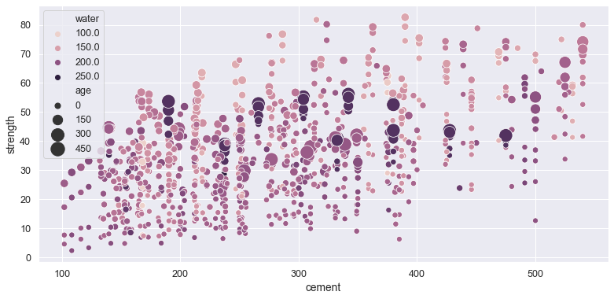

```python
plt.figure(figsize=(13,6))
sns.scatterplot(y="strength", x="cement", hue="water",size="age", data=concrete_df, sizes=(50, 300))
```

## Observations

Compressive strength increases as the amount of cement increases  
Compressive strength increases with age  
Cement with less age requires more cement for higher strength  
The older the cement is the more water it requires

## 3. Feature Engineering techniques (10 marks)

```
a. Identify opportunities (if any) to extract a new feature from existing features, drop a feature (if required)

b. Get data model ready and do a train test split.

c. Decide on complexity of the model, should it be simple linear model in terms of parameters or would a quadratic or higher degree.
```

## New field : w/c water to cement ratio:

A key factor in concrete engineering is the water-cement ratio.

```python
concrete_df['w/c'] = concrete_df['water']/concrete_df['cement']
```

```
w/c: Range :  0.26689252776209305 - 1.8823529411764706
w/c: Mean :  0.7562204591194337
w/c: Median :  0.6895306859205776
w/c: Std Dev :  0.3135243571316141
w/c: Lower outliers :  -0.03719989987935268
w/c: upper outliers :  1.521905493509613
w/c: Number of outliers in  upper :  18
w/c: Number of outliers in  lower :  0
w/c: % of Outlier in  upper:  2.0 %
w/c: % of Outlier in  lower:  0.0 %
```

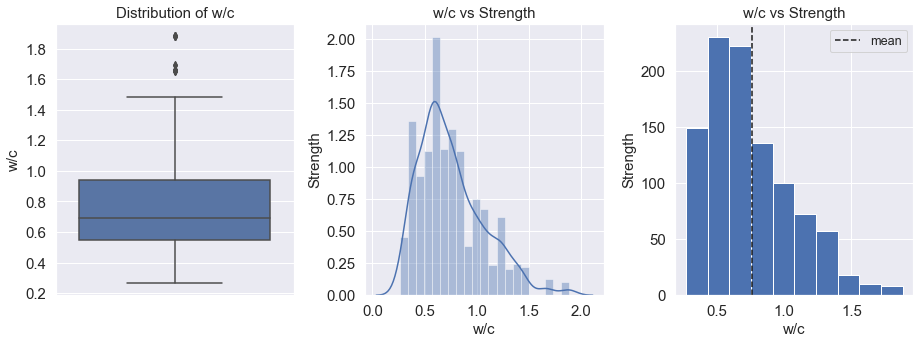

```python
df_col_analysis(concrete_df,'w/c', 'Strength')
```

```python
concrete_df.head()
```

|  | cement | slag | ash | water | superplastic | coarseagg | fineagg | age | strength | cs_binned | w/c |
| --- | --- | --- | --- | --- | --- | --- | --- | --- | --- | --- | --- |
| 0 | 141.3 | 212.0 | 0.0 | 203.5 | 0.0 | 971.8 | 748.5 | 28 | 29.89 | 4 | 1.440198 |
| 1 | 168.9 | 42.2 | 124.3 | 158.3 | 10.8 | 1080.8 | 796.2 | 14 | 23.51 | 3 | 0.937241 |
| 2 | 250.0 | 0.0 | 95.7 | 187.4 | 5.5 | 956.9 | 861.2 | 28 | 29.22 | 4 | 0.749600 |
| 3 | 266.0 | 114.0 | 0.0 | 228.0 | 0.0 | 932.0 | 670.0 | 28 | 45.85 | 6 | 0.857143 |
| 4 | 154.8 | 183.4 | 0.0 | 193.3 | 9.1 | 1047.4 | 696.7 | 28 | 18.29 | 2 | 1.248708 |

```python
#independent and dependent variables
X=concrete_df[[x for x in concrete_df.columns if x not in ["strength" ,"water", "cement", "cs_binned" ]]]
#.iloc[:,0:8]
y = concrete_df['strength']
```

```python
X
```

|  | slag | ash | superplastic | coarseagg | fineagg | age | w/c |
| --- | --- | --- | --- | --- | --- | --- | --- |
| 0 | 212.0 | 0.0 | 0.0 | 971.8 | 748.5 | 28 | 1.440198 |
| 1 | 42.2 | 124.3 | 10.8 | 1080.8 | 796.2 | 14 | 0.937241 |
| 2 | 0.0 | 95.7 | 5.5 | 956.9 | 861.2 | 28 | 0.749600 |
| 3 | 114.0 | 0.0 | 0.0 | 932.0 | 670.0 | 28 | 0.857143 |
| 4 | 183.4 | 0.0 | 9.1 | 1047.4 | 696.7 | 28 | 1.248708 |
| ... | ... | ... | ... | ... | ... | ... | ... |
| 1025 | 0.0 | 166.0 | 10.0 | 961.0 | 805.0 | 28 | 1.333333 |
| 1026 | 0.0 | 0.0 | 28.2 | 852.1 | 893.7 | 3 | 0.266893 |
| 1027 | 116.0 | 90.3 | 8.9 | 870.1 | 768.3 | 28 | 0.649783 |
| 1028 | 38.0 | 0.0 | 0.0 | 932.0 | 670.0 | 270 | 0.666667 |
| 1029 | 0.0 | 0.0 | 0.0 | 1125.0 | 613.0 | 7 | 0.320370 |

1005 rows × 7 columns

```python
# Split X and y into training and test set in 70:30 ratio
X_train, X_test, y_train, y_test = train_test_split(X,y, test_size = 0.3, random_state = 123)
```

```python
sc = StandardScaler()
X_train = sc.fit_transform(X_train)
X_test = sc.transform(X_test)
```

```python
X_train =pd.DataFrame(X_train,columns=X.columns)
```

## Analysis

based on the bivariate analysis , the relationship of Stregth with other varibles doesnt seem linear in nature. hence Linear model might not work.

### 2. Creating the model and tuning it

1. Algorithms that you think will be suitable for this project (at least 3 algorithms). Use Kfold Cross Validation to evaluate model performance. Use appropriate metrics and make a DataFrame to compare models w.r.t their metrics. (15 marks)

### Suitable Algorithm

Linear Regression : might not work as relation ship doesnt seem linear.  
DecisionTreeRegressor  
RandomForestRegressor Ada Boost Regressor

```python
results_df = pd.DataFrame()

def execute_model(results_df, testName, dt_model, dtrainX, dtrainy, dtestX, dtesty, of_type, cv=True):
    print (dt_model)
    print("Columns:",dtrainX.columns)
    dt_model=dt_model.fit(dtrainX, dtrainy)
    y_pred = dt_model.predict(dtestX)
    actual=dtesty
    predicted=y_pred

    tr_acc=dt_model.score(dtrainX,dtrainy)
    tst_acc=dt_model.score(dtestX, dtesty)
    acc_DT=metrics.r2_score(dtesty, y_pred)
    mse=metrics.mean_squared_error(dtesty, y_pred)
    rmse=np.sqrt(mse)
    print()
    print("Training accuracy",tr_acc)
    print()
    print("Testing accuracy",tst_acc)
    print()
    print('MEAN SQUARED ERROR: ',mse)
    print ("ROOT MEAN SQUARED ERROR :", np.sqrt(mean_squared_error(dtesty,predicted)) )

    plt.figure(figsize=(12,6))

    #printing the feature importance
    if of_type == "feat":
        print('Feature importances: \n',pd.DataFrame(dt_model.feature_importances_,columns=['Imp'],index=X_train.columns).sort_values(by=['Imp'], ascending=False))
        coef = pd.DataFrame(dt_model.feature_importances_)
        coef["feat"] = dtrainX.columns
        ax2 = sns.barplot(coef["feat"],coef[0],palette="jet_r",
                          linewidth=2,edgecolor="k"*coef["feat"].nunique())
        ax2.set_facecolor("lightgrey")
        ax2.axhline(0,color="k",linewidth=2)
        plt.ylabel("coefficients")
        plt.xlabel("features")
        plt.title('FEATURE IMPORTANCES')
    elif of_type == "coef":
        print('Coefficient importances: \n',pd.DataFrame(dt_model.coef_, X.columns, columns=['Coefficient']).sort_values(by=['Coefficient'], ascending=False))
        coef = pd.DataFrame(dt_model.coef_.ravel())
        coef["feat"] = dtrainX.columns
        ax1 = sns.barplot(coef["feat"],coef[0],palette="jet_r",
                          linewidth=2,edgecolor="k"*coef["feat"].nunique())
        ax1.set_facecolor("lightgrey")
        ax1.axhline(0,color="k",linewidth=2)
        plt.ylabel("coefficients")
        plt.xlabel("features")
        plt.title('FEATURE IMPORTANCES')
    elif of_type == "hyper":
        best_hyperparams = dt_model.best_params_
        print('Best hyerparameters:\n', best_hyperparams)

    cv_r2_mean=float("nan")
    stdDev=float("nan")
    if (cv) :
        num_folds = 10
        seed = 77
        kfold = KFold(n_splits=num_folds, random_state=seed)
        cross_val_rl = cross_val_score(dt_model,X, y, cv=kfold, scoring='r2')
        cv_r2_mean=np.mean(abs(cross_val_rl))
        stdDev=cross_val_rl.std()
        print ("CROSS VALIDATION SCORE")
        print ("************************")
        print('R2 mean: ',cv_r2_mean)
        print('Standard Deviation: ',stdDev)
        cross_val = cross_val_rl.ravel()
        print ("cv-mean :",cross_val.mean())
        print ("cv-std  :",cross_val.std())
        print ("cv-max  :",cross_val.max())
        print ("cv-min  :",cross_val.min())


    resultMap= {'1_TestName' : testName, '1_cols_count': dtrainX.columns.size, '2_TrainingAccuracy' : tr_acc,
            '3_TestingAccuracy' : tst_acc, '3_r2_Acc':acc_DT,'4_MSE':mse, '4_RMSE':rmse,'5_KFold_R2_Mean' : cv_r2_mean,
            '5_KFold_Std_Dev' : stdDev}
    results_df=results_df.append(resultMap,ignore_index=True)

    return results_df;
```

## Linear Regression

```
LinearRegression(copy_X=True, fit_intercept=True, n_jobs=None, normalize=False)
Columns: Index(['slag', 'ash', 'superplastic', 'coarseagg', 'fineagg', 'age', 'w/c'], dtype='object')

Training accuracy 0.5388179640104085

Testing accuracy 0.5770364128214072

MEAN SQUARED ERROR:  117.16356452512514
ROOT MEAN SQUARED ERROR : 10.824211958619673
Coefficient importances:
               Coefficient
age              6.598226
slag             6.261705
superplastic     3.583773
ash              2.408066
fineagg         -0.277874
coarseagg       -0.548399
w/c             -9.821152
CROSS VALIDATION SCORE
R2 mean:  0.5250151230963083
Standard Deviation:  0.0856210076495526
cv-mean : 0.5250151230963083
cv-std  : 0.0856210076495526
cv-max  : 0.7108707468570629
cv-min  : 0.4255900840282275
```

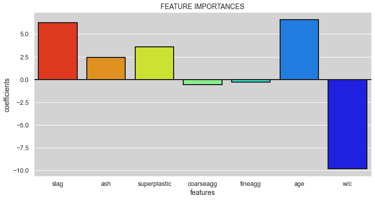

```python
dt_model = LinearRegression()
results_df= execute_model(results_df,"LinearRegression",dt_model,X_train, y_train,X_test, y_test, "coef")
```

```python
results_df
```

|  | 1_TestName | 1_cols_count | 2_TrainingAccuracy | 3_TestingAccuracy | 3_r2_Acc | 4_MSE | 4_RMSE | 5_KFold_R2_Mean | 5_KFold_Std_Dev |
| --- | --- | --- | --- | --- | --- | --- | --- | --- | --- |
| 0 | LinearRegression | 7.0 | 0.538818 | 0.577036 | 0.577036 | 117.163565 | 10.824212 | 0.525015 | 0.085621 |

## DecisionTreeRegressor

```
DecisionTreeRegressor(criterion='mse', max_depth=None, max_features=None,
                      max_leaf_nodes=None, min_impurity_decrease=0.0,
                      min_impurity_split=None, min_samples_leaf=1,
                      min_samples_split=2, min_weight_fraction_leaf=0.0,
                      presort=False, random_state=None, splitter='best')
Columns: Index(['slag', 'ash', 'superplastic', 'coarseagg', 'fineagg', 'age', 'w/c'], dtype='object')

Training accuracy 0.9996953123434869

Testing accuracy 0.7990372133731084

MEAN SQUARED ERROR:  55.667951407284775
ROOT MEAN SQUARED ERROR : 7.461095858336413
Feature importances:
                    Imp
w/c           0.404376
age           0.353460
slag          0.093581
superplastic  0.065925
fineagg       0.034941
coarseagg     0.032545
ash           0.015173
CROSS VALIDATION SCORE
R2 mean:  0.852743467331784
Standard Deviation:  0.05322956092476398
cv-mean : 0.852743467331784
cv-std  : 0.05322956092476398
cv-max  : 0.9370201270711762
cv-min  : 0.7394195666476826
```

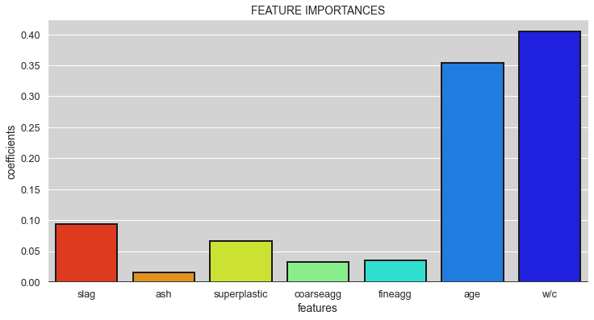

```python
dt_model = DecisionTreeRegressor()
results_df= execute_model(results_df,"DecisionTreeRegressor",dt_model,X_train, y_train,X_test, y_test, "feat")
```

```python
results_df
```

|  | 1_TestName | 1_cols_count | 2_TrainingAccuracy | 3_TestingAccuracy | 3_r2_Acc | 4_MSE | 4_RMSE | 5_KFold_R2_Mean | 5_KFold_Std_Dev |
| --- | --- | --- | --- | --- | --- | --- | --- | --- | --- |
| 0 | LinearRegression | 7.0 | 0.538818 | 0.577036 | 0.577036 | 117.163565 | 10.824212 | 0.525015 | 0.085621 |
| 1 | DecisionTreeRegressor | 7.0 | 0.999695 | 0.799037 | 0.799037 | 55.667951 | 7.461096 | 0.852743 | 0.053230 |

## RandomForestRegressor

```
RandomForestRegressor(bootstrap=True, criterion='mse', max_depth=None,
                      max_features='auto', max_leaf_nodes=None,
                      min_impurity_decrease=0.0, min_impurity_split=None,
                      min_samples_leaf=1, min_samples_split=2,
                      min_weight_fraction_leaf=0.0, n_estimators='warn',
                      n_jobs=None, oob_score=False, random_state=None,
                      verbose=0, warm_start=False)
Columns: Index(['slag', 'ash', 'superplastic', 'coarseagg', 'fineagg', 'age', 'w/c'], dtype='object')

Training accuracy 0.978106439845014

Testing accuracy 0.8680247580950993

MEAN SQUARED ERROR:  36.557969147625094
ROOT MEAN SQUARED ERROR : 6.04631864423511
Feature importances:
                    Imp
w/c           0.384905
age           0.378541
slag          0.088540
superplastic  0.053377
fineagg       0.045513
coarseagg     0.031576
ash           0.017549
CROSS VALIDATION SCORE
R2 mean:  0.8990174332138497
Standard Deviation:  0.03485918573113983
cv-mean : 0.8990174332138497
cv-std  : 0.03485918573113983
cv-max  : 0.9481138640206913
cv-min  : 0.8141841705229687
```

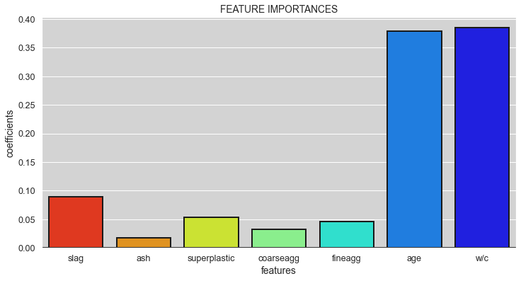

```python
dt_model = RandomForestRegressor()
results_df= execute_model(results_df,"RandomForestRegressor",dt_model,X_train, y_train,X_test, y_test, "feat")
```

## Ada Boost Regressor

```
AdaBoostRegressor(base_estimator=None, learning_rate=1.0, loss='linear',
                  n_estimators=50, random_state=None)
Columns: Index(['slag', 'ash', 'superplastic', 'coarseagg', 'fineagg', 'age', 'w/c'], dtype='object')

Training accuracy 0.8175411443064983

Testing accuracy 0.7942918928350188

MEAN SQUARED ERROR:  56.982434937097786
ROOT MEAN SQUARED ERROR : 7.548671070930153
Feature importances:
                    Imp
w/c           0.415039
age           0.280192
slag          0.124809
superplastic  0.098918
fineagg       0.044837
coarseagg     0.035851
ash           0.000354
CROSS VALIDATION SCORE
R2 mean:  0.7712548657835384
Standard Deviation:  0.03652335590930606
cv-mean : 0.7712548657835384
cv-std  : 0.03652335590930606
cv-max  : 0.8404201261815584
cv-min  : 0.6956081974385757
```

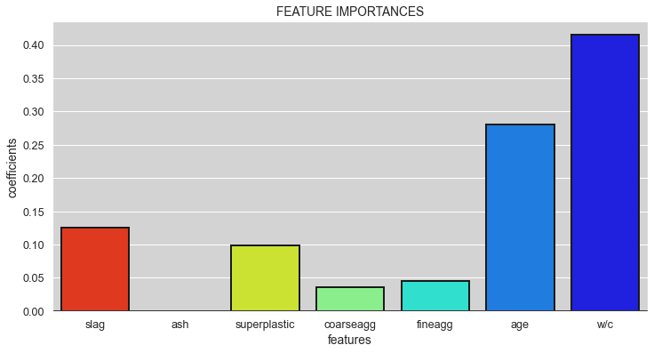

```python
from sklearn.ensemble import AdaBoostRegressor
dt_model = AdaBoostRegressor()
results_df= execute_model(results_df,"AdaBoostRegressor",dt_model,X_train, y_train,X_test, y_test, "feat")
```

## Dropping "coarseagg","fineagg","ash"

Based on the feature importance analysis, ("coarseagg","fineagg","ash") has quite less significant impact. So, we can drop these.

```python
#independent and dependent variables
X=concrete_df[[x for x in concrete_df.columns if x not in ["strength" ,"water", "cement", "coarseagg","fineagg","ash","cs_binned"]]]
#.iloc[:,0:8]
y = concrete_df['strength']
```

```python
# Split X and y into training and test set in 70:30 ratio
X_train, X_test, y_train, y_test = train_test_split(X,y, test_size = 0.3, random_state = 123)
```

```
DecisionTreeRegressor(criterion='mse', max_depth=None, max_features=None,
                      max_leaf_nodes=None, min_impurity_decrease=0.0,
                      min_impurity_split=None, min_samples_leaf=1,
                      min_samples_split=2, min_weight_fraction_leaf=0.0,
                      presort=False, random_state=None, splitter='best')
Columns: Index(['slag', 'superplastic', 'age', 'w/c'], dtype='object')

Training accuracy 0.9985227997242627

Testing accuracy 0.8121901615189088

MEAN SQUARED ERROR:  52.024502336276676
ROOT MEAN SQUARED ERROR : 7.212801282184105
Feature importances:
                    Imp
w/c           0.444358
age           0.354041
slag          0.112071
superplastic  0.089530
CROSS VALIDATION SCORE
R2 mean:  0.8424194641982048
Standard Deviation:  0.054822802488919534
cv-mean : 0.8424194641982048
cv-std  : 0.054822802488919534
cv-max  : 0.9216516836888964
cv-min  : 0.7184251153744575
```

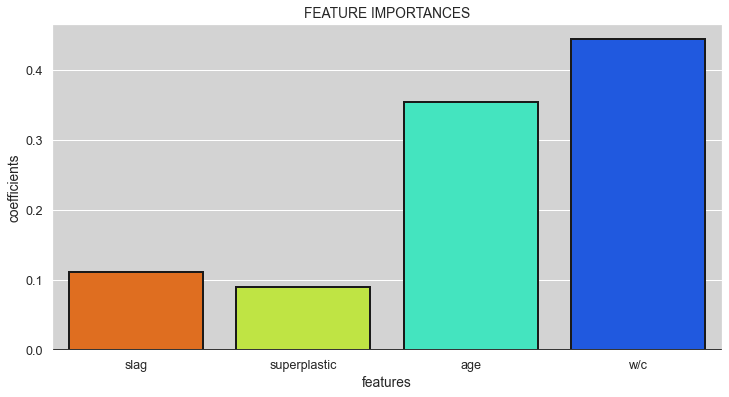

```python
## Run again with column optimization
dt_model = DecisionTreeRegressor()
results_df= execute_model(results_df,"DecisionTreeRegressor2",dt_model,X_train, y_train,X_test, y_test, "feat")
```

```
LinearRegression(copy_X=True, fit_intercept=True, n_jobs=None, normalize=False)
Columns: Index(['slag', 'superplastic', 'age', 'w/c'], dtype='object')

Training accuracy 0.5258923595601044

Testing accuracy 0.5625353397412838

MEAN SQUARED ERROR:  121.18045265216199
ROOT MEAN SQUARED ERROR : 11.008199337410364
Coefficient importances:
               Coefficient
superplastic     0.847945
age              0.098716
slag             0.060621
w/c            -27.999681
CROSS VALIDATION SCORE
R2 mean:  0.5136586227064821
Standard Deviation:  0.08993172590701587
cv-mean : 0.5136586227064821
cv-std  : 0.08993172590701587
cv-max  : 0.726436094457682
cv-min  : 0.41380126171253195
```

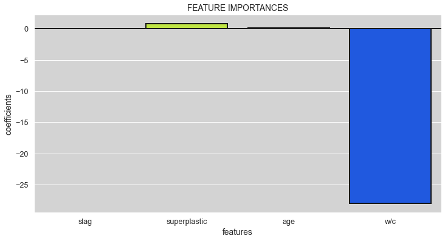

```python
dt_model = LinearRegression()
results_df= execute_model(results_df,"LinearRegression2",dt_model,X_train, y_train,X_test, y_test, "coef")
```

```
AdaBoostRegressor(base_estimator=None, learning_rate=1.0, loss='linear',
                  n_estimators=50, random_state=None)
Columns: Index(['slag', 'superplastic', 'age', 'w/c'], dtype='object')

Training accuracy 0.8193125440894939

Testing accuracy 0.7873153361944971

MEAN SQUARED ERROR:  58.91498485130536
ROOT MEAN SQUARED ERROR : 7.675609738079794
Feature importances:
                    Imp
w/c           0.462517
age           0.279503
slag          0.141454
superplastic  0.116526
CROSS VALIDATION SCORE
R2 mean:  0.7618858313976957
Standard Deviation:  0.037097366196978045
cv-mean : 0.7618858313976957
cv-std  : 0.037097366196978045
cv-max  : 0.8281853722075548
cv-min  : 0.7073961238285726
```

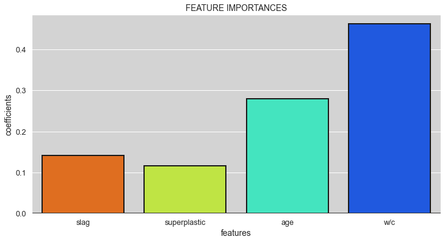

```python
from sklearn.ensemble import AdaBoostRegressor
dt_model = AdaBoostRegressor()
results_df= execute_model(results_df,"AdaBoostRegressor2",dt_model,X_train, y_train,X_test, y_test, "feat")
```

```
RandomForestRegressor(bootstrap=True, criterion='mse', max_depth=None,
                      max_features='auto', max_leaf_nodes=None,
                      min_impurity_decrease=0.0, min_impurity_split=None,
                      min_samples_leaf=1, min_samples_split=2,
                      min_weight_fraction_leaf=0.0, n_estimators='warn',
                      n_jobs=None, oob_score=False, random_state=None,
                      verbose=0, warm_start=False)
Columns: Index(['slag', 'superplastic', 'age', 'w/c'], dtype='object')

Training accuracy 0.9760780974221105

Testing accuracy 0.8458503598341472

MEAN SQUARED ERROR:  42.700416441452965
ROOT MEAN SQUARED ERROR : 6.534555565717761
Feature importances:
                    Imp
w/c           0.409452
age           0.382502
slag          0.110977
superplastic  0.097069
CROSS VALIDATION SCORE
R2 mean:  0.8860403142788172
Standard Deviation:  0.037337994951933746
cv-mean : 0.8860403142788172
cv-std  : 0.037337994951933746
cv-max  : 0.9255249836264938
cv-min  : 0.7934069462588967
```

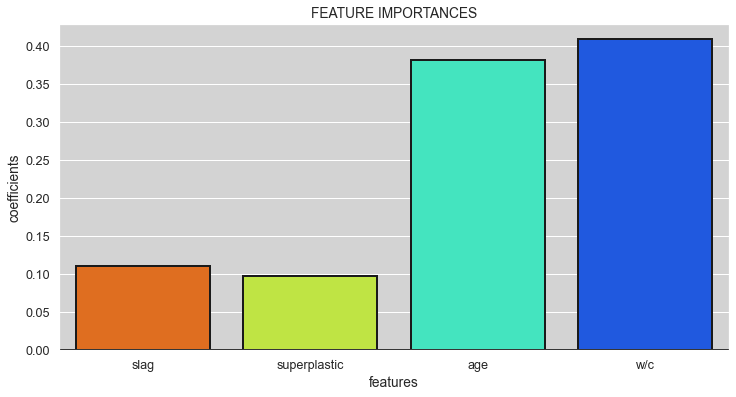

```python
dt_model = RandomForestRegressor()
results_df= execute_model(results_df,"RandomForestRegressor2",dt_model,X_train, y_train,X_test, y_test, "feat")
```

```python
results_df
```

|  | 1_TestName | 1_cols_count | 2_TrainingAccuracy | 3_TestingAccuracy | 3_r2_Acc | 4_MSE | 4_RMSE | 5_KFold_R2_Mean | 5_KFold_Std_Dev |
| --- | --- | --- | --- | --- | --- | --- | --- | --- | --- |
| 0 | LinearRegression | 7.0 | 0.538818 | 0.577036 | 0.577036 | 117.163565 | 10.824212 | 0.525015 | 0.085621 |
| 1 | DecisionTreeRegressor | 7.0 | 0.999695 | 0.799037 | 0.799037 | 55.667951 | 7.461096 | 0.852743 | 0.053230 |
| 2 | RandomForestRegressor | 7.0 | 0.978106 | 0.868025 | 0.868025 | 36.557969 | 6.046319 | 0.899017 | 0.034859 |
| 3 | AdaBoostRegressor | 7.0 | 0.817541 | 0.794292 | 0.794292 | 56.982435 | 7.548671 | 0.771255 | 0.036523 |
| 4 | DecisionTreeRegressor2 | 4.0 | 0.998523 | 0.812190 | 0.812190 | 52.024502 | 7.212801 | 0.842419 | 0.054823 |
| 5 | LinearRegression2 | 4.0 | 0.525892 | 0.562535 | 0.562535 | 121.180453 | 11.008199 | 0.513659 | 0.089932 |
| 6 | AdaBoostRegressor2 | 4.0 | 0.819313 | 0.787315 | 0.787315 | 58.914985 | 7.675610 | 0.761886 | 0.037097 |
| 7 | RandomForestRegressor2 | 4.0 | 0.976078 | 0.845850 | 0.845850 | 42.700416 | 6.534556 | 0.886040 | 0.037338 |

## 2. Techniques employed to squeeze that extra performance out of the model without making it over fit. Use Grid Search or Random Search on any of the two models used above. Make a DataFrame to compare models after hyperparameter tuning and their metrics as above. (15 marks)

```python
from sklearn.model_selection import GridSearchCV

parameters = {'bootstrap': [True],
 'max_depth': [10, 20, 30, 40, 50,100],
 'max_features': ['auto', 'sqrt'],
 'min_samples_leaf': [1, 2, 4, 8],
 'n_estimators': [100]}


dt_model = GridSearchCV(RandomForestRegressor(), parameters, cv = 5, verbose = 2, n_jobs= 4)
results_df= execute_model(results_df,"GridSearchCV-RandomForestRegressor2",dt_model,X_train, y_train,X_test, y_test, "hyper", False)
```

```
GridSearchCV(cv=5, error_score='raise-deprecating',
             estimator=RandomForestRegressor(bootstrap=True, criterion='mse',
                                             max_depth=None,
                                             max_features='auto',
                                             max_leaf_nodes=None,
                                             min_impurity_decrease=0.0,
                                             min_impurity_split=None,
                                             min_samples_leaf=1,
                                             min_samples_split=2,
                                             min_weight_fraction_leaf=0.0,
                                             n_estimators='warn', n_jobs=None,
                                             oob_score=False, random_state=None,
                                             verbose=0, warm_start=False),
             iid='warn', n_jobs=4,
             param_grid={'bootstrap': [True],
                         'max_depth': [10, 20, 30, 40, 50, 100],
                         'max_features': ['auto', 'sqrt'],
                         'min_samples_leaf': [1, 2, 4, 8],
                         'n_estimators': [100]},
             pre_dispatch='2*n_jobs', refit=True, return_train_score=False,
             scoring=None, verbose=2)
Columns: Index(['slag', 'superplastic', 'age', 'w/c'], dtype='object')
Fitting 5 folds for each of 48 candidates, totalling 240 fits
```

```
[Parallel(n_jobs=4)]: Using backend LokyBackend with 4 concurrent workers.
[Parallel(n_jobs=4)]: Done  33 tasks      | elapsed:    2.8s
[Parallel(n_jobs=4)]: Done 154 tasks      | elapsed:    7.5s
```

```
Training accuracy 0.9832150483245472

Testing accuracy 0.8732463152765874

MEAN SQUARED ERROR:  35.111565082831255
ROOT MEAN SQUARED ERROR : 5.9255012516099645
Best hyerparameters:
 {'bootstrap': True, 'max_depth': 50, 'max_features': 'sqrt', 'min_samples_leaf': 1, 'n_estimators': 100}
```

```
[Parallel(n_jobs=4)]: Done 240 out of 240 | elapsed:   11.3s finished
```

```python
from sklearn.model_selection import GridSearchCV

parameters = {'fit_intercept':[True,False], 'normalize':[True,False], 'copy_X':[True, False]}


dt_model = GridSearchCV(LinearRegression(), parameters, cv = 5, verbose = 2, n_jobs= 4)


results_df= execute_model(results_df,"GridSearchCV-LinearRegression2",dt_model,X_train, y_train,X_test, y_test, "hyper",False)
```

```
[Parallel(n_jobs=4)]: Using backend LokyBackend with 4 concurrent workers.
```

```
GridSearchCV(cv=5, error_score='raise-deprecating',
             estimator=LinearRegression(copy_X=True, fit_intercept=True,
                                        n_jobs=None, normalize=False),
             iid='warn', n_jobs=4,
             param_grid={'copy_X': [True, False],
                         'fit_intercept': [True, False],
                         'normalize': [True, False]},
             pre_dispatch='2*n_jobs', refit=True, return_train_score=False,
             scoring=None, verbose=2)
Columns: Index(['slag', 'superplastic', 'age', 'w/c'], dtype='object')
Fitting 5 folds for each of 8 candidates, totalling 40 fits

Training accuracy 0.5258923595601044

Testing accuracy 0.5625353397412838

MEAN SQUARED ERROR:  121.18045265216199
ROOT MEAN SQUARED ERROR : 11.008199337410364
Best hyerparameters:
 {'copy_X': True, 'fit_intercept': True, 'normalize': True}
```

```
[Parallel(n_jobs=4)]: Done  40 out of  40 | elapsed:    0.1s finished
```

```python
from sklearn.model_selection import GridSearchCV

parameters = {
             "max_depth": [None, 1, 2, 3, 4, 5, 6, 7],
             "min_samples_leaf": range(1, 3),
             "min_samples_split": range(2, 10),
             "max_leaf_nodes": range(10,18)}


dt_model = GridSearchCV(DecisionTreeRegressor(), parameters, cv = 5, verbose = 2, n_jobs= 4)


results_df= execute_model(results_df,"GridSearchCV-DecisionTreeRegressor",dt_model,X_train, y_train,X_test, y_test, "hyper",False)
```

```
GridSearchCV(cv=5, error_score='raise-deprecating',
             estimator=DecisionTreeRegressor(criterion='mse', max_depth=None,
                                             max_features=None,
                                             max_leaf_nodes=None,
                                             min_impurity_decrease=0.0,
                                             min_impurity_split=None,
                                             min_samples_leaf=1,
                                             min_samples_split=2,
                                             min_weight_fraction_leaf=0.0,
                                             presort=False, random_state=None,
                                             splitter='best'),
             iid='warn', n_jobs=4,
             param_grid={'max_depth': [None, 1, 2, 3, 4, 5, 6, 7],
                         'max_leaf_nodes': range(10, 18),
                         'min_samples_leaf': range(1, 3),
                         'min_samples_split': range(2, 10)},
             pre_dispatch='2*n_jobs', refit=True, return_train_score=False,
             scoring=None, verbose=2)
Columns: Index(['slag', 'superplastic', 'age', 'w/c'], dtype='object')
Fitting 5 folds for each of 1024 candidates, totalling 5120 fits
```

```
[Parallel(n_jobs=4)]: Using backend LokyBackend with 4 concurrent workers.
[Parallel(n_jobs=4)]: Done 758 tasks      | elapsed:    2.0s
[Parallel(n_jobs=4)]: Done 4388 tasks      | elapsed:   10.7s
```

```
Training accuracy 0.7686583012028643

Testing accuracy 0.6855442816397339

MEAN SQUARED ERROR:  87.10620480159933
ROOT MEAN SQUARED ERROR : 9.33307049162275
Best hyerparameters:
 {'max_depth': 5, 'max_leaf_nodes': 16, 'min_samples_leaf': 1, 'min_samples_split': 2}
```

```
[Parallel(n_jobs=4)]: Done 5120 out of 5120 | elapsed:   12.4s finished
```

```python
results_df
```

|  | 1_TestName | 1_cols_count | 2_TrainingAccuracy | 3_TestingAccuracy | 3_r2_Acc | 4_MSE | 4_RMSE | 5_KFold_R2_Mean | 5_KFold_Std_Dev |
| --- | --- | --- | --- | --- | --- | --- | --- | --- | --- |
| 0 | LinearRegression | 7.0 | 0.538818 | 0.577036 | 0.577036 | 117.163565 | 10.824212 | 0.525015 | 0.085621 |
| 1 | DecisionTreeRegressor | 7.0 | 0.999695 | 0.799037 | 0.799037 | 55.667951 | 7.461096 | 0.852743 | 0.053230 |
| 2 | RandomForestRegressor | 7.0 | 0.978106 | 0.868025 | 0.868025 | 36.557969 | 6.046319 | 0.899017 | 0.034859 |
| 3 | AdaBoostRegressor | 7.0 | 0.817541 | 0.794292 | 0.794292 | 56.982435 | 7.548671 | 0.771255 | 0.036523 |
| 4 | DecisionTreeRegressor2 | 4.0 | 0.998523 | 0.812190 | 0.812190 | 52.024502 | 7.212801 | 0.842419 | 0.054823 |
| 5 | LinearRegression2 | 4.0 | 0.525892 | 0.562535 | 0.562535 | 121.180453 | 11.008199 | 0.513659 | 0.089932 |
| 6 | AdaBoostRegressor2 | 4.0 | 0.819313 | 0.787315 | 0.787315 | 58.914985 | 7.675610 | 0.761886 | 0.037097 |
| 7 | RandomForestRegressor2 | 4.0 | 0.976078 | 0.845850 | 0.845850 | 42.700416 | 6.534556 | 0.886040 | 0.037338 |
| 8 | GridSearchCV-RandomForestRegressor2 | 4.0 | 0.983215 | 0.873246 | 0.873246 | 35.111565 | 5.925501 | NaN | NaN |
| 9 | GridSearchCV-LinearRegression2 | 4.0 | 0.525892 | 0.562535 | 0.562535 | 121.180453 | 11.008199 | NaN | NaN |
| 10 | GridSearchCV-DecisionTreeRegressor | 4.0 | 0.768658 | 0.685544 | 0.685544 | 87.106205 | 9.333070 | NaN | NaN |

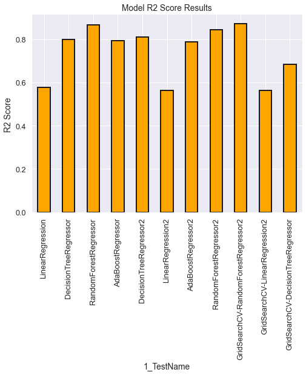

```python
results_df.set_index('1_TestName', inplace = True)
results_df['3_r2_Acc'].plot.bar(color = 'orange', figsize = (8, 6),
                                 edgecolor = 'k', linewidth = 2)
plt.title('Model R2 Score Results');
plt.ylabel('R2 Score ');
```

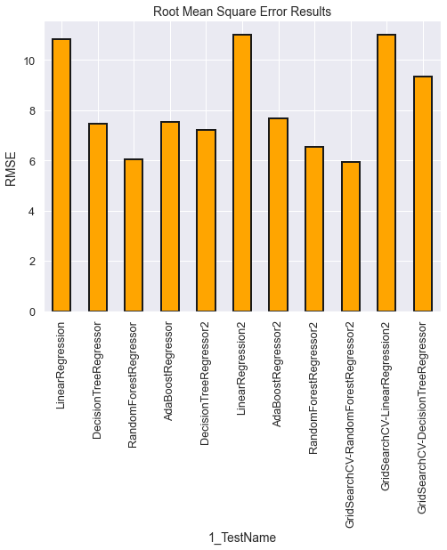

```python
results_df['4_RMSE'].plot.bar(color = 'orange', figsize = (8, 6),
                                 edgecolor = 'k', linewidth = 2)
plt.title('Root Mean Square Error Results');
plt.ylabel('RMSE ');
```

In used algorithms, RandomForestRegressor is performing best among others. Best hyerparameters: {'bootstrap': True, 'max_depth': 50, 'max_features': 'sqrt', 'min_samples_leaf': 1, 'n_estimators': 100}

## Other Algos that can be used:

Regression: Polynomial, SVM, Ridge and Lasso  
Boosting Algorithms: AdaBoost, Gradient Boosting and XGBoost